# [Back to Course Website](http://ericdunford.com/ppol670/) Data Acquisition Using `R` Package APIs

PPOL 670 | Introduction to Data Science

Professor Eric Dunford (ed769@georgetown.edu) McCourt School of Public Policy, Georgetown University

# Overview

There are more streamlined ways to extract data from external sources. Let’s explore some `R` package that provide wrapper for useful APIs to streamline data extraction and acquisition.

# Google Trends Data

## What is it?

What is [Google Trends](https://trends.google.com/trends/?geo=US)? “Google Trends is a website by Google that analyzes the popularity of top search queries in Google Search across various regions and languages. The website uses graphs to compare the search volume of different queries over time.” - Wikipedia

## Package(s)

- [`gtrendsR`](https://cran.r-project.org/web/packages/gtrendsR/gtrendsR.pdf): An interface for retrieving and displaying the information returned online by Google Trends is provided. Trends (number of hits) over the time as well as geographic representation of the results can be displayed.
- [`trendyy`](https://cran.r-project.org/web/packages/trendyy/trendyy.pdf): a tidy wrapper to the `gtrendsR` package.

## Installation

```r
install.packages("gtrendsR")
install.packages("trendyy")
```

```r
require(trendyy)
```

## Usage

```r
# Specify the search terms you're interested in.
my_search_terms <- c("Biden","trump")

# Download the term activity across a specific period using the Google Trends API
trends <- trendy(search_terms = my_search_terms,
                 from = "2020-09-01",to="2020-09-30")
```

Clean and examine the data.

```r
# Trends sends you back a lot of data. Use trendyy's helper functions to get
# what we want: search term interest over time.
dat_trends <- get_interest(trends)
dat_trends
```

| date | hits | keyword | geo | time | gprop | category |
| --- | --- | --- | --- | --- | --- | --- |
| 2020-09-01 | 28 | Biden | world | 2020-09-01 2020-09-30 | web | All categories |
| 2020-09-02 | 25 | Biden | world | 2020-09-01 2020-09-30 | web | All categories |
| 2020-09-03 | 23 | Biden | world | 2020-09-01 2020-09-30 | web | All categories |
| 2020-09-04 | 25 | Biden | world | 2020-09-01 2020-09-30 | web | All categories |
| 2020-09-05 | 24 | Biden | world | 2020-09-01 2020-09-30 | web | All categories |
| 2020-09-06 | 21 | Biden | world | 2020-09-01 2020-09-30 | web | All categories |
| 2020-09-07 | 21 | Biden | world | 2020-09-01 2020-09-30 | web | All categories |
| 2020-09-08 | 22 | Biden | world | 2020-09-01 2020-09-30 | web | All categories |
| 2020-09-09 | 21 | Biden | world | 2020-09-01 2020-09-30 | web | All categories |
| 2020-09-10 | 21 | Biden | world | 2020-09-01 2020-09-30 | web | All categories |

[output cut: 44 more lines]

Visualize.

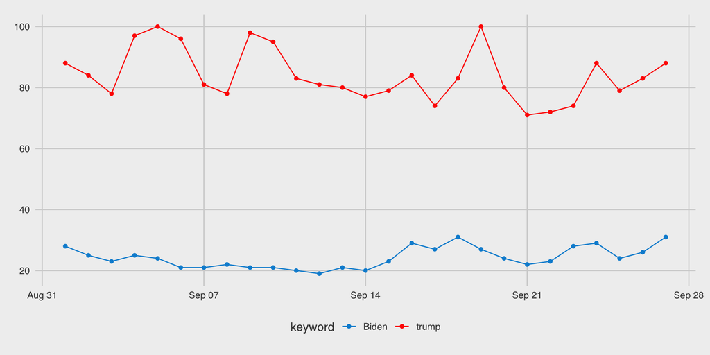

```r
# Note: tidyverse is loaded.
dat_trends %>%
  ggplot(aes(date,hits,color=keyword)) +
  geom_line() +
  geom_point() +
  ggthemes::scale_color_fivethirtyeight() +
  ggthemes::theme_fivethirtyeight()
```

We can target specific geographic regions with the `geo =` argument. To know which geographic code corresponds to a specific instance, we need to look at `gtrendsR`.

```r
geo_codes <- as_tibble(gtrendsR::countries)
geo_codes
```

| country_code | sub_code | name |
| --- | --- | --- |
| AF | NA | AFGHANISTAN |
| AF | AF-BDS | BADAKHSHAN |
| AF | AF-BDG | BADGHIS |
| AF | AF-BGL | BAGHLAN |
| AF | AF-BAL | BALKH |
| AF | AF-BAM | BAMIAN |
| AF | AF-FRA | FARAH |
| AF | AF-FYB | FARYAB |
| AF | AF-GHA | GHAZNI |
| AF | AF-GHO | GHOWR |

[output cut: 9990 more lines]

```r
# Extract trends just for the US. Also we can draw out larger time windows
trends_us <- trendy(search_terms = my_search_terms,
                    from = "2004-01-01",to="2020-09-30",
                    geo="US")

# Draw out relevant content
dat_trends_us <- get_interest(trends_us)
dat_trends_us
```

| date | hits | keyword | geo | time | gprop | category |
| --- | --- | --- | --- | --- | --- | --- |
| 2004-01-01 | 1 | Biden | US | 2004-01-01 2020-09-30 | web | All categories |
| 2004-02-01 | 1 | Biden | US | 2004-01-01 2020-09-30 | web | All categories |
| 2004-03-01 | 1 | Biden | US | 2004-01-01 2020-09-30 | web | All categories |
| 2004-04-01 | 1 | Biden | US | 2004-01-01 2020-09-30 | web | All categories |
| 2004-05-01 | 1 | Biden | US | 2004-01-01 2020-09-30 | web | All categories |
| 2004-06-01 | 1 | Biden | US | 2004-01-01 2020-09-30 | web | All categories |
| 2004-07-01 | 1 | Biden | US | 2004-01-01 2020-09-30 | web | All categories |
| 2004-08-01 | 1 | Biden | US | 2004-01-01 2020-09-30 | web | All categories |
| 2004-09-01 | 1 | Biden | US | 2004-01-01 2020-09-30 | web | All categories |
| 2004-10-01 | 1 | Biden | US | 2004-01-01 2020-09-30 | web | All categories |

[output cut: 392 more lines]

Visualize again.

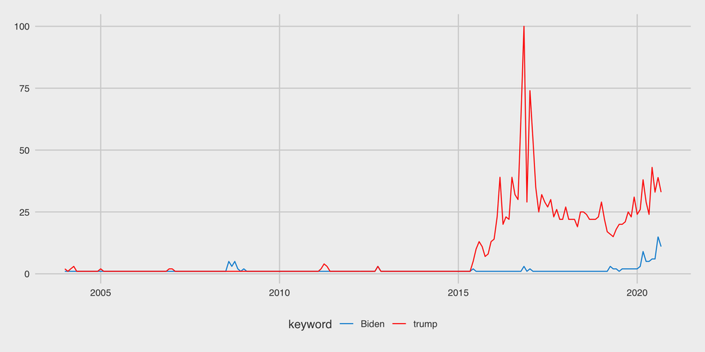

```r
# Visualize
dat_trends_us %>%
  ggplot(aes(date,hits,color=keyword)) +
  geom_line() +
  ggthemes::scale_color_fivethirtyeight() +
  ggthemes::theme_fivethirtyeight()
```

## Limitations

- **Normalized search terms** means that content is relative to the words searched. We can’t back out search volumn.
- Can only search for **5 keywords** at a time.
- Can only request **1000 queries** a day.
- Choosing the correct keywords can be difficult. Language matters.

# World Bank Development Indicators Data

## What is it?

World Development Indicators (WDI) is the primary World Bank collection of development indicators, compiled from officially recognized international sources. It presents the most current and accurate global development data available, and includes national, regional and global estimates.

## Package

- [`wbstats`](https://cran.r-project.org/web/packages/wbstats/wbstats.pdf): Programmatic Access to Data and Statistics from the World Bank API

## Installation

```r
install.packages("wbstats")
```

```r
require(wbstats)
```

## Usage

Search for specific measured concepts.

```r
# Look up indicators related to GDP.
gdp_ind <- wbsearch(pattern = "gdp")
gdp_ind
```

|  | indicatorID | indicator |
| --- | --- | --- |
| 676 | 5.51.01.10.gdp | Per capita GDP growth |
| 678 | 6.0.GDP_current | GDP (current $) |
| 679 | 6.0.GDP_growth | GDP growth (annual %) |
| 680 | 6.0.GDP_usd | GDP (constant 2005 $) |
| 681 | 6.0.GDPpc_constant | GDP per capita, PPP (constant 2011 international $) |
| 1521 | BG.GSR.NFSV.GD.ZS | Trade in services (% of GDP) |
| 1522 | BG.KAC.FNEI.GD.PP.ZS | Gross private capital flows (% of GDP, PPP) |
| 1523 | BG.KAC.FNEI.GD.ZS | Gross private capital flows (% of GDP) |
| 1524 | BG.KLT.DINV.GD.PP.ZS | Gross foreign direct investment (% of GDP, PPP) |
| 1525 | BG.KLT.DINV.GD.ZS | Gross foreign direct investment (% of GDP) |

[output cut: 631 more lines]

Download data for a specific indicator.

```r
# Download info on the GDP (current US$)
wb_dat <- wb(indicator = "NY.GDP.MKTP.CD", # Use the indicator id
             country = "countries_only", # Avoid regional designations
             startdate = 2000, enddate=2005)
```

Look at the data

```r
glimpse(wb_dat)
```

```
## Rows: 1,216
## Columns: 7
## $ iso3c       <chr> "ABW", "ABW", "ABW", "ABW", "ABW", "ABW", "AFG", "AFG", "…
## $ date        <chr> "2005", "2004", "2003", "2002", "2001", "2000", "2005", "…
## $ value       <dbl> 2330726257, 2228491620, 2021229050, 1941340782, 192011173…
## $ indicatorID <chr> "NY.GDP.MKTP.CD", "NY.GDP.MKTP.CD", "NY.GDP.MKTP.CD", "NY…
## $ indicator   <chr> "GDP (current US$)", "GDP (current US$)", "GDP (current U…
## $ iso2c       <chr> "AW", "AW", "AW", "AW", "AW", "AW", "AF", "AF", "AF", "AF…
## $ country     <chr> "Aruba", "Aruba", "Aruba", "Aruba", "Aruba", "Aruba", "Af…
```

Plot the average log GDP by year.

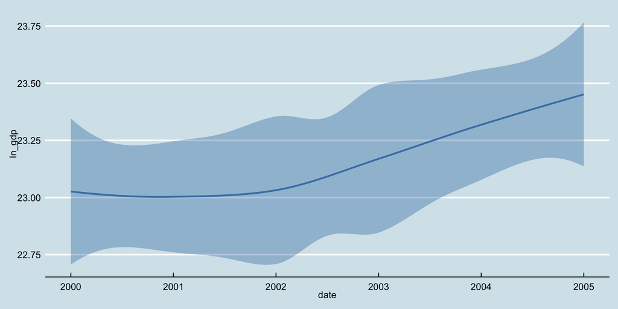

```r
wb_dat %>%
  mutate(date = as.numeric(date),
         ln_gdp = log(value)) %>%
  ggplot(aes(date,ln_gdp)) +
  geom_smooth(method="loess",color="steelblue",fill="steelblue") +
  ggthemes::theme_economist()
```

# Reddit Data

## What is it?

“Reddit is an American social news aggregation, web content rating, and discussion website. Registered members submit content to the site such as links, text posts, and images, which are then voted up or down by other members.” - Wikipedia

## Package

- [`rreddit`](https://github.com/mkearney/rreddit)

## Installation

```r
if (!requireNamespace("remotes")) {
  install.packages("remotes")
}

# Not published on CRAN, must download from Github
remotes::install_github("mkearney/rreddit")
```